# Risk Factor Analysis

## Outcome Variable

**Outcome Variable:** haz

## Predictor Variables

**Intervention Variable:** brthmon

**Adjustment Set:**

unadjusted

## Stratifying Variables

The analysis was stratified on these variable(s):

- agecat
- studyid
- country

## Data Summary

| agecat | studyid | country | brthmon | n_cell | n | outcome_variable |
| --- | --- | --- | --- | --- | --- | --- |
| Birth | CMC-V-BCS-2002 | INDIA | 1 | 9 | 92 | haz |
| Birth | CMC-V-BCS-2002 | INDIA | 2 | 1 | 92 | haz |
| Birth | CMC-V-BCS-2002 | INDIA | 3 | 8 | 92 | haz |
| Birth | CMC-V-BCS-2002 | INDIA | 4 | 9 | 92 | haz |
| Birth | CMC-V-BCS-2002 | INDIA | 5 | 12 | 92 | haz |
| Birth | CMC-V-BCS-2002 | INDIA | 6 | 9 | 92 | haz |
| Birth | CMC-V-BCS-2002 | INDIA | 7 | 7 | 92 | haz |
| Birth | CMC-V-BCS-2002 | INDIA | 8 | 4 | 92 | haz |
| Birth | CMC-V-BCS-2002 | INDIA | 9 | 8 | 92 | haz |
| Birth | CMC-V-BCS-2002 | INDIA | 10 | 10 | 92 | haz |
| Birth | CMC-V-BCS-2002 | INDIA | 11 | 11 | 92 | haz |
| Birth | CMC-V-BCS-2002 | INDIA | 12 | 4 | 92 | haz |
| Birth | CMIN | BANGLADESH | 1 | 5 | 26 | haz |
| Birth | CMIN | BANGLADESH | 2 | 4 | 26 | haz |
| Birth | CMIN | BANGLADESH | 3 | 0 | 26 | haz |
| Birth | CMIN | BANGLADESH | 4 | 3 | 26 | haz |
| Birth | CMIN | BANGLADESH | 5 | 1 | 26 | haz |
| Birth | CMIN | BANGLADESH | 6 | 0 | 26 | haz |
| Birth | CMIN | BANGLADESH | 7 | 4 | 26 | haz |
| Birth | CMIN | BANGLADESH | 8 | 4 | 26 | haz |
| Birth | CMIN | BANGLADESH | 9 | 1 | 26 | haz |
| Birth | CMIN | BANGLADESH | 10 | 1 | 26 | haz |
| Birth | CMIN | BANGLADESH | 11 | 3 | 26 | haz |
| Birth | CMIN | BANGLADESH | 12 | 0 | 26 | haz |
| Birth | CONTENT | PERU | 1 | 0 | 2 | haz |
| Birth | CONTENT | PERU | 2 | 0 | 2 | haz |
| Birth | CONTENT | PERU | 3 | 0 | 2 | haz |
| Birth | CONTENT | PERU | 4 | 0 | 2 | haz |
| Birth | CONTENT | PERU | 5 | 2 | 2 | haz |
| Birth | CONTENT | PERU | 6 | 0 | 2 | haz |

[output cut: 810 more lines]

The following strata were considered:

- agecat: 24 months, studyid: CMC-V-BCS-2002, country: INDIA
- agecat: 24 months, studyid: CMIN, country: BANGLADESH
- agecat: 24 months, studyid: CONTENT, country: PERU
- agecat: 24 months, studyid: EE, country: PAKISTAN
- agecat: 24 months, studyid: GMS-Nepal, country: NEPAL
- agecat: 24 months, studyid: IRC, country: INDIA
- agecat: 24 months, studyid: JiVitA-3, country: BANGLADESH
- agecat: 24 months, studyid: JiVitA-4, country: BANGLADESH
- agecat: 24 months, studyid: Keneba, country: GAMBIA
- agecat: 24 months, studyid: LCNI-5, country: MALAWI
- agecat: 24 months, studyid: MAL-ED, country: BANGLADESH
- agecat: 24 months, studyid: MAL-ED, country: BRAZIL
- agecat: 24 months, studyid: MAL-ED, country: INDIA
- agecat: 24 months, studyid: MAL-ED, country: NEPAL
- agecat: 24 months, studyid: MAL-ED, country: PERU
- agecat: 24 months, studyid: MAL-ED, country: SOUTH AFRICA
- agecat: 24 months, studyid: MAL-ED, country: TANZANIA, UNITED REPUBLIC OF
- agecat: 24 months, studyid: NIH-Birth, country: BANGLADESH
- agecat: 24 months, studyid: PROBIT, country: BELARUS
- agecat: 24 months, studyid: PROVIDE, country: BANGLADESH
- agecat: 24 months, studyid: TanzaniaChild2, country: TANZANIA, UNITED REPUBLIC OF
- agecat: 24 months, studyid: ZVITAMBO, country: ZIMBABWE
- agecat: 6 months, studyid: CMC-V-BCS-2002, country: INDIA
- agecat: 6 months, studyid: CMIN, country: BANGLADESH
- agecat: 6 months, studyid: CONTENT, country: PERU
- agecat: 6 months, studyid: EE, country: PAKISTAN
- agecat: 6 months, studyid: GMS-Nepal, country: NEPAL
- agecat: 6 months, studyid: Guatemala BSC, country: GUATEMALA
- agecat: 6 months, studyid: IRC, country: INDIA
- agecat: 6 months, studyid: JiVitA-3, country: BANGLADESH
- agecat: 6 months, studyid: JiVitA-4, country: BANGLADESH
- agecat: 6 months, studyid: Keneba, country: GAMBIA
- agecat: 6 months, studyid: LCNI-5, country: MALAWI
- agecat: 6 months, studyid: MAL-ED, country: BANGLADESH
- agecat: 6 months, studyid: MAL-ED, country: BRAZIL
- agecat: 6 months, studyid: MAL-ED, country: INDIA
- agecat: 6 months, studyid: MAL-ED, country: NEPAL
- agecat: 6 months, studyid: MAL-ED, country: PERU
- agecat: 6 months, studyid: MAL-ED, country: SOUTH AFRICA
- agecat: 6 months, studyid: MAL-ED, country: TANZANIA, UNITED REPUBLIC OF
- agecat: 6 months, studyid: NIH-Birth, country: BANGLADESH
- agecat: 6 months, studyid: PROBIT, country: BELARUS
- agecat: 6 months, studyid: PROVIDE, country: BANGLADESH
- agecat: 6 months, studyid: ResPak, country: PAKISTAN
- agecat: 6 months, studyid: SAS-CompFeed, country: INDIA
- agecat: 6 months, studyid: SAS-FoodSuppl, country: INDIA
- agecat: 6 months, studyid: TanzaniaChild2, country: TANZANIA, UNITED REPUBLIC OF
- agecat: 6 months, studyid: ZVITAMBO, country: ZIMBABWE
- agecat: Birth, studyid: CMC-V-BCS-2002, country: INDIA
- agecat: Birth, studyid: CMIN, country: BANGLADESH
- agecat: Birth, studyid: CONTENT, country: PERU
- agecat: Birth, studyid: EE, country: PAKISTAN
- agecat: Birth, studyid: GMS-Nepal, country: NEPAL
- agecat: Birth, studyid: IRC, country: INDIA
- agecat: Birth, studyid: JiVitA-3, country: BANGLADESH
- agecat: Birth, studyid: JiVitA-4, country: BANGLADESH
- agecat: Birth, studyid: Keneba, country: GAMBIA
- agecat: Birth, studyid: MAL-ED, country: BANGLADESH
- agecat: Birth, studyid: MAL-ED, country: BRAZIL
- agecat: Birth, studyid: MAL-ED, country: INDIA
- agecat: Birth, studyid: MAL-ED, country: NEPAL
- agecat: Birth, studyid: MAL-ED, country: PERU
- agecat: Birth, studyid: MAL-ED, country: SOUTH AFRICA
- agecat: Birth, studyid: MAL-ED, country: TANZANIA, UNITED REPUBLIC OF
- agecat: Birth, studyid: NIH-Birth, country: BANGLADESH
- agecat: Birth, studyid: PROBIT, country: BELARUS
- agecat: Birth, studyid: PROVIDE, country: BANGLADESH
- agecat: Birth, studyid: ResPak, country: PAKISTAN
- agecat: Birth, studyid: SAS-CompFeed, country: INDIA
- agecat: Birth, studyid: ZVITAMBO, country: ZIMBABWE

### Dropped Strata

Some strata were dropped due to rare outcomes:

- agecat: Birth, studyid: CMC-V-BCS-2002, country: INDIA
- agecat: Birth, studyid: CMIN, country: BANGLADESH
- agecat: Birth, studyid: CONTENT, country: PERU
- agecat: Birth, studyid: EE, country: PAKISTAN
- agecat: Birth, studyid: GMS-Nepal, country: NEPAL
- agecat: Birth, studyid: JiVitA-4, country: BANGLADESH
- agecat: Birth, studyid: MAL-ED, country: BRAZIL
- agecat: Birth, studyid: MAL-ED, country: INDIA
- agecat: Birth, studyid: MAL-ED, country: NEPAL
- agecat: Birth, studyid: MAL-ED, country: SOUTH AFRICA
- agecat: Birth, studyid: ResPak, country: PAKISTAN
- agecat: 6 months, studyid: EE, country: PAKISTAN
- agecat: 6 months, studyid: GMS-Nepal, country: NEPAL
- agecat: 6 months, studyid: JiVitA-4, country: BANGLADESH
- agecat: 6 months, studyid: ResPak, country: PAKISTAN
- agecat: 6 months, studyid: SAS-FoodSuppl, country: INDIA
- agecat: 24 months, studyid: EE, country: PAKISTAN
- agecat: 24 months, studyid: GMS-Nepal, country: NEPAL
- agecat: 24 months, studyid: JiVitA-4, country: BANGLADESH
- agecat: 24 months, studyid: TanzaniaChild2, country: TANZANIA, UNITED REPUBLIC OF

## Methods Detail

We’re interested in the causal parameters $E[Y_a]$ for all values of $a \in \mathcal{A}$. These parameters represent the mean outcome if, possibly contrary to fact, we intervened to set all units to have $A=a$. Under the randomization and positivity assumptions, these are identified by the statistical parameters $\psi_a=E_W[E_{Y|A,W}(Y|A=a,W)]$. In addition, we’re interested in the mean of $Y$, $E[Y]$ under no intervention (the observed mean). We will estimate these parameters by using SuperLearner to fit the relevant likelihood factors – $E_{Y|A,W}(Y|A=a,W)$ and $p(A=a|W)$, and then updating our likelihood fit using a joint TMLE.

For unadjusted analyses ($W=\{\}$), initial likelihoods were estimated using Lrnr_glm to estimate the simple $E(Y|A)$ and Lrnr_mean to estimate $p(A)$. For adjusted analyses, a small library containing Lrnr_glmnet, Lrnr_xgboost, and Lrnr_mean was used.

Having estimated these parameters, we will then use the delta method to estimate relative risks and attributable risks relative to a prespecified baseline level of $A$.

# Results Detail

## Results Plots

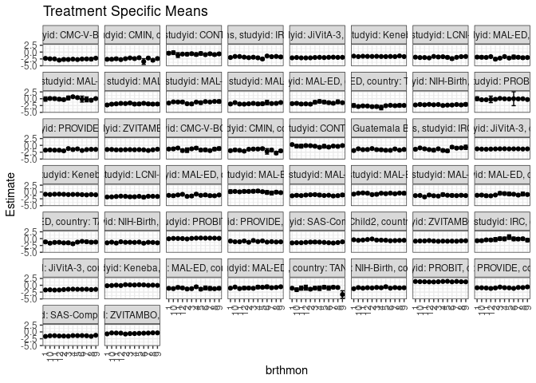

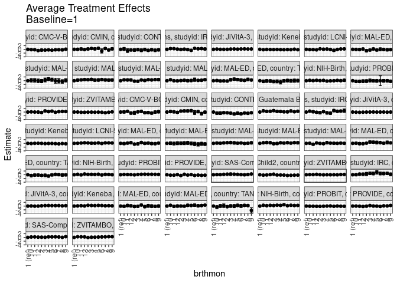

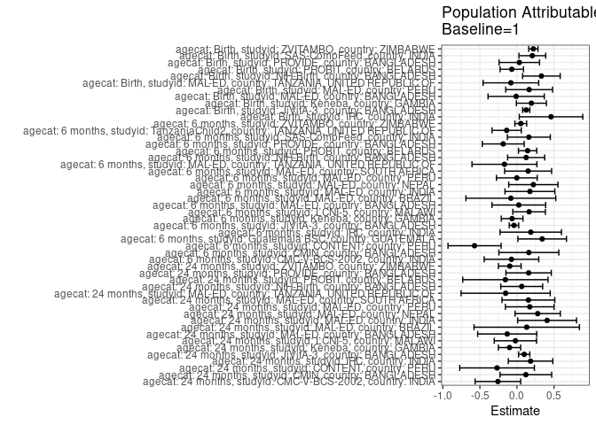

## Results Table

### Parameter: TSM

| agecat | studyid | country | intervention_level | baseline_level | estimate | ci_lower | ci_upper |
| --- | --- | --- | --- | --- | --- | --- | --- |
| Birth | IRC | INDIA | 1 | NA | -0.7685714 | -1.2073155 | -0.3298273 |
| Birth | IRC | INDIA | 2 | NA | -0.3334615 | -1.0314327 | 0.3645096 |
| Birth | IRC | INDIA | 3 | NA | -0.0276923 | -0.6276724 | 0.5722878 |
| Birth | IRC | INDIA | 4 | NA | -0.0933333 | -0.7295115 | 0.5428448 |
| Birth | IRC | INDIA | 5 | NA | 0.5545455 | -0.2742674 | 1.3833583 |
| Birth | IRC | INDIA | 6 | NA | -0.0935294 | -0.7447207 | 0.5576619 |
| Birth | IRC | INDIA | 7 | NA | -0.1402857 | -0.6755232 | 0.3949518 |
| Birth | IRC | INDIA | 8 | NA | -0.0405263 | -0.5173421 | 0.4362895 |
| Birth | IRC | INDIA | 9 | NA | -0.5456000 | -1.1368551 | 0.0456551 |
| Birth | IRC | INDIA | 10 | NA | -0.7465789 | -1.1805916 | -0.3125663 |
| Birth | IRC | INDIA | 11 | NA | -0.4523077 | -0.8407487 | -0.0638667 |
| Birth | IRC | INDIA | 12 | NA | -0.4936735 | -0.9566175 | -0.0307294 |
| Birth | JiVitA-3 | BANGLADESH | 1 | NA | -1.7146373 | -1.7660163 | -1.6632583 |
| Birth | JiVitA-3 | BANGLADESH | 2 | NA | -1.5733583 | -1.6339172 | -1.5127994 |
| Birth | JiVitA-3 | BANGLADESH | 3 | NA | -1.4550171 | -1.5091993 | -1.4008350 |
| Birth | JiVitA-3 | BANGLADESH | 4 | NA | -1.4259797 | -1.4846871 | -1.3672722 |
| Birth | JiVitA-3 | BANGLADESH | 5 | NA | -1.4723584 | -1.5519704 | -1.3927464 |
| Birth | JiVitA-3 | BANGLADESH | 6 | NA | -1.4736518 | -1.5539125 | -1.3933910 |
| Birth | JiVitA-3 | BANGLADESH | 7 | NA | -1.4554517 | -1.5304991 | -1.3804043 |
| Birth | JiVitA-3 | BANGLADESH | 8 | NA | -1.5899545 | -1.6502431 | -1.5296659 |
| Birth | JiVitA-3 | BANGLADESH | 9 | NA | -1.4949378 | -1.5486633 | -1.4412124 |
| Birth | JiVitA-3 | BANGLADESH | 10 | NA | -1.6497335 | -1.7035233 | -1.5959437 |
| Birth | JiVitA-3 | BANGLADESH | 11 | NA | -1.7558481 | -1.8077557 | -1.7039404 |
| Birth | JiVitA-3 | BANGLADESH | 12 | NA | -1.7201740 | -1.7665197 | -1.6738283 |
| Birth | Keneba | GAMBIA | 1 | NA | -0.1641718 | -0.3804133 | 0.0520698 |
| Birth | Keneba | GAMBIA | 2 | NA | 0.2219048 | 0.0201423 | 0.4236672 |
| Birth | Keneba | GAMBIA | 3 | NA | 0.1420000 | -0.0301259 | 0.3141259 |
| Birth | Keneba | GAMBIA | 4 | NA | 0.0933333 | -0.1233964 | 0.3100630 |
| Birth | Keneba | GAMBIA | 5 | NA | 0.1775926 | -0.0745293 | 0.4297144 |
| Birth | Keneba | GAMBIA | 6 | NA | 0.1317978 | -0.1151595 | 0.3787550 |

[output cut: 570 more lines]

### Parameter: E(Y)

| agecat | studyid | country | intervention_level | baseline_level | estimate | ci_lower | ci_upper |
| --- | --- | --- | --- | --- | --- | --- | --- |
| Birth | IRC | INDIA | NA | NA | -0.3080412 | -0.4687931 | -0.1472894 |
| Birth | JiVitA-3 | BANGLADESH | NA | NA | -1.5894148 | -1.6086362 | -1.5701935 |
| Birth | Keneba | GAMBIA | NA | NA | 0.0308036 | -0.0328378 | 0.0944451 |
| Birth | MAL-ED | BANGLADESH | NA | NA | -1.1180952 | -1.2525408 | -0.9836496 |
| Birth | MAL-ED | PERU | NA | NA | -0.8827897 | -1.0001058 | -0.7654736 |
| Birth | MAL-ED | TANZANIA, UNITED REPUBLIC OF | NA | NA | -1.1556000 | -1.3655361 | -0.9456639 |
| Birth | NIH-Birth | BANGLADESH | NA | NA | -0.9310197 | -1.0197391 | -0.8423003 |
| Birth | PROBIT | BELARUS | NA | NA | 1.3114417 | 1.1524752 | 1.4704082 |
| Birth | PROVIDE | BANGLADESH | NA | NA | -0.8851020 | -0.9601332 | -0.8100709 |
| Birth | SAS-CompFeed | INDIA | NA | NA | -1.4314217 | -1.5099245 | -1.3529189 |
| Birth | ZVITAMBO | ZIMBABWE | NA | NA | -0.5002724 | -0.5208163 | -0.4797285 |
| 6 months | CMC-V-BCS-2002 | INDIA | NA | NA | -1.4234508 | -1.5645974 | -1.2823042 |
| 6 months | CMIN | BANGLADESH | NA | NA | -1.7844376 | -1.9222926 | -1.6465825 |
| 6 months | CONTENT | PERU | NA | NA | -0.2785256 | -0.4098735 | -0.1471776 |
| 6 months | Guatemala BSC | GUATEMALA | NA | NA | -1.5619008 | -1.6727702 | -1.4510313 |
| 6 months | IRC | INDIA | NA | NA | -1.2344062 | -1.3658524 | -1.1029600 |
| 6 months | JiVitA-3 | BANGLADESH | NA | NA | -1.3130932 | -1.3362359 | -1.2899505 |
| 6 months | Keneba | GAMBIA | NA | NA | -0.9041369 | -0.9513363 | -0.8569376 |
| 6 months | LCNI-5 | MALAWI | NA | NA | -1.6601907 | -1.7297701 | -1.5906113 |
| 6 months | MAL-ED | BANGLADESH | NA | NA | -1.2049931 | -1.3222136 | -1.0877726 |
| 6 months | MAL-ED | BRAZIL | NA | NA | 0.0475758 | -0.0963508 | 0.1915023 |
| 6 months | MAL-ED | INDIA | NA | NA | -1.2115254 | -1.3298727 | -1.0931782 |
| 6 months | MAL-ED | NEPAL | NA | NA | -0.5615819 | -0.6741832 | -0.4489807 |
| 6 months | MAL-ED | PERU | NA | NA | -1.3236661 | -1.4316775 | -1.2156546 |
| 6 months | MAL-ED | SOUTH AFRICA | NA | NA | -1.0633202 | -1.1909180 | -0.9357224 |
| 6 months | MAL-ED | TANZANIA, UNITED REPUBLIC OF | NA | NA | -1.3687449 | -1.4907629 | -1.2467270 |
| 6 months | NIH-Birth | BANGLADESH | NA | NA | -1.4073821 | -1.4960598 | -1.3187043 |
| 6 months | PROBIT | BELARUS | NA | NA | 0.0980074 | 0.0062724 | 0.1897424 |
| 6 months | PROVIDE | BANGLADESH | NA | NA | -1.0916915 | -1.1661176 | -1.0172654 |
| 6 months | SAS-CompFeed | INDIA | NA | NA | -1.4018563 | -1.4810585 | -1.3226541 |
| 6 months | TanzaniaChild2 | TANZANIA, UNITED REPUBLIC OF | NA | NA | -0.5434389 | -0.5924056 | -0.4944722 |
| 6 months | ZVITAMBO | ZIMBABWE | NA | NA | -0.8679450 | -0.8935071 | -0.8423828 |
| 24 months | CMC-V-BCS-2002 | INDIA | NA | NA | -2.5588679 | -2.6583730 | -2.4593629 |
| 24 months | CMIN | BANGLADESH | NA | NA | -2.5109504 | -2.6361514 | -2.3857494 |
| 24 months | CONTENT | PERU | NA | NA | -0.6868598 | -0.8388476 | -0.5348719 |
| 24 months | IRC | INDIA | NA | NA | -1.7987775 | -1.8923914 | -1.7051636 |
| 24 months | JiVitA-3 | BANGLADESH | NA | NA | -2.0136481 | -2.0413552 | -1.9859409 |
| 24 months | Keneba | GAMBIA | NA | NA | -1.5774356 | -1.6272400 | -1.5276311 |
| 24 months | LCNI-5 | MALAWI | NA | NA | -1.8861485 | -1.9671802 | -1.8051169 |
| 24 months | MAL-ED | BANGLADESH | NA | NA | -1.9783962 | -2.1050210 | -1.8517715 |
| 24 months | MAL-ED | BRAZIL | NA | NA | 0.0061144 | -0.1625850 | 0.1748138 |
| 24 months | MAL-ED | INDIA | NA | NA | -1.8861894 | -2.0110006 | -1.7613783 |
| 24 months | MAL-ED | NEPAL | NA | NA | -1.3075877 | -1.4270718 | -1.1881037 |
| 24 months | MAL-ED | PERU | NA | NA | -1.7524710 | -1.8736426 | -1.6312994 |
| 24 months | MAL-ED | SOUTH AFRICA | NA | NA | -1.6450595 | -1.7797240 | -1.5103950 |
| 24 months | MAL-ED | TANZANIA, UNITED REPUBLIC OF | NA | NA | -2.6455607 | -2.7807256 | -2.5103959 |
| 24 months | NIH-Birth | BANGLADESH | NA | NA | -2.2190579 | -2.3217459 | -2.1163699 |
| 24 months | PROBIT | BELARUS | NA | NA | -0.1442891 | -0.4253755 | 0.1367972 |
| 24 months | PROVIDE | BANGLADESH | NA | NA | -1.6024221 | -1.6857420 | -1.5191023 |
| 24 months | ZVITAMBO | ZIMBABWE | NA | NA | -1.6055701 | -1.6625562 | -1.5485840 |

### Parameter: ATE

| agecat | studyid | country | intervention_level | baseline_level | estimate | ci_lower | ci_upper |
| --- | --- | --- | --- | --- | --- | --- | --- |
| Birth | IRC | INDIA | 1 | 1 | 0.0000000 | 0.0000000 | 0.0000000 |
| Birth | IRC | INDIA | 2 | 1 | 0.4351099 | -0.3893051 | 1.2595249 |
| Birth | IRC | INDIA | 3 | 1 | 0.7408791 | -0.0024058 | 1.4841641 |
| Birth | IRC | INDIA | 4 | 1 | 0.6752381 | -0.0975614 | 1.4480376 |
| Birth | IRC | INDIA | 5 | 1 | 1.3231169 | 0.3853391 | 2.2608946 |
| Birth | IRC | INDIA | 6 | 1 | 0.6750420 | -0.1101627 | 1.4602468 |
| Birth | IRC | INDIA | 7 | 1 | 0.6282857 | -0.0637949 | 1.3203664 |
| Birth | IRC | INDIA | 8 | 1 | 0.7280451 | 0.0800870 | 1.3760032 |
| Birth | IRC | INDIA | 9 | 1 | 0.2229714 | -0.5132887 | 0.9592316 |
| Birth | IRC | INDIA | 10 | 1 | 0.0219925 | -0.5951488 | 0.6391338 |
| Birth | IRC | INDIA | 11 | 1 | 0.3162637 | -0.2697250 | 0.9022525 |
| Birth | IRC | INDIA | 12 | 1 | 0.2748980 | -0.3629215 | 0.9127174 |
| Birth | JiVitA-3 | BANGLADESH | 1 | 1 | 0.0000000 | 0.0000000 | 0.0000000 |
| Birth | JiVitA-3 | BANGLADESH | 2 | 1 | 0.1412790 | 0.0596740 | 0.2228840 |
| Birth | JiVitA-3 | BANGLADESH | 3 | 1 | 0.2596201 | 0.1866223 | 0.3326179 |
| Birth | JiVitA-3 | BANGLADESH | 4 | 1 | 0.2886576 | 0.2116711 | 0.3656441 |
| Birth | JiVitA-3 | BANGLADESH | 5 | 1 | 0.2422789 | 0.1466307 | 0.3379270 |
| Birth | JiVitA-3 | BANGLADESH | 6 | 1 | 0.2409855 | 0.1464235 | 0.3355475 |
| Birth | JiVitA-3 | BANGLADESH | 7 | 1 | 0.2591856 | 0.1703933 | 0.3479779 |
| Birth | JiVitA-3 | BANGLADESH | 8 | 1 | 0.1246827 | 0.0444370 | 0.2049285 |
| Birth | JiVitA-3 | BANGLADESH | 9 | 1 | 0.2196994 | 0.1476456 | 0.2917533 |
| Birth | JiVitA-3 | BANGLADESH | 10 | 1 | 0.0649038 | -0.0043507 | 0.1341582 |
| Birth | JiVitA-3 | BANGLADESH | 11 | 1 | -0.0412108 | -0.1113096 | 0.0288880 |
| Birth | JiVitA-3 | BANGLADESH | 12 | 1 | -0.0055367 | -0.0742231 | 0.0631496 |
| Birth | Keneba | GAMBIA | 1 | 1 | 0.0000000 | 0.0000000 | 0.0000000 |
| Birth | Keneba | GAMBIA | 2 | 1 | 0.3860765 | 0.0903258 | 0.6818273 |
| Birth | Keneba | GAMBIA | 3 | 1 | 0.3061718 | 0.0297885 | 0.5825551 |
| Birth | Keneba | GAMBIA | 4 | 1 | 0.2575051 | -0.0486520 | 0.5636622 |
| Birth | Keneba | GAMBIA | 5 | 1 | 0.3417644 | 0.0096110 | 0.6739177 |
| Birth | Keneba | GAMBIA | 6 | 1 | 0.2959695 | -0.0322808 | 0.6242199 |

[output cut: 570 more lines]

### Parameter: PAR

| agecat | studyid | country | intervention_level | baseline_level | estimate | ci_lower | ci_upper |
| --- | --- | --- | --- | --- | --- | --- | --- |
| Birth | IRC | INDIA | 1 | NA | 0.4605302 | 0.0320342 | 0.8890262 |
| Birth | JiVitA-3 | BANGLADESH | 1 | NA | 0.1252224 | 0.0769416 | 0.1735033 |
| Birth | Keneba | GAMBIA | 1 | NA | 0.1949754 | -0.0073393 | 0.3972902 |
| Birth | MAL-ED | BANGLADESH | 1 | NA | -0.0105952 | -0.3901220 | 0.3689315 |
| Birth | MAL-ED | PERU | 1 | NA | 0.1648770 | -0.1513841 | 0.4811380 |
| Birth | MAL-ED | TANZANIA, UNITED REPUBLIC OF | 1 | NA | -0.0816000 | -0.4571381 | 0.2939381 |
| Birth | NIH-Birth | BANGLADESH | 1 | NA | 0.3302660 | 0.0764159 | 0.5841161 |
| Birth | PROBIT | BELARUS | 1 | NA | -0.0693028 | -0.2271199 | 0.0885143 |
| Birth | PROVIDE | BANGLADESH | 1 | NA | 0.0322313 | -0.2406375 | 0.3051001 |
| Birth | SAS-CompFeed | INDIA | 1 | NA | 0.2078806 | 0.0272573 | 0.3885039 |
| Birth | ZVITAMBO | ZIMBABWE | 1 | NA | 0.2215369 | 0.1591179 | 0.2839560 |
| 6 months | CMC-V-BCS-2002 | INDIA | 1 | NA | -0.0737939 | -0.4421570 | 0.2945692 |
| 6 months | CMIN | BANGLADESH | 1 | NA | 0.1607547 | -0.2436720 | 0.5651814 |
| 6 months | CONTENT | PERU | 1 | NA | -0.5721256 | -0.9307056 | -0.2135456 |
| 6 months | Guatemala BSC | GUATEMALA | 1 | NA | 0.3408968 | 0.0129613 | 0.6688324 |
| 6 months | IRC | INDIA | 1 | NA | 0.1868657 | -0.2279610 | 0.6016924 |
| 6 months | JiVitA-3 | BANGLADESH | 1 | NA | -0.0402052 | -0.1040227 | 0.0236124 |
| 6 months | Keneba | GAMBIA | 1 | NA | -0.0655480 | -0.2120240 | 0.0809279 |
| 6 months | LCNI-5 | MALAWI | 1 | NA | 0.1640740 | -0.0558159 | 0.3839639 |
| 6 months | MAL-ED | BANGLADESH | 1 | NA | 0.0251921 | -0.3373398 | 0.3877240 |
| 6 months | MAL-ED | BRAZIL | 1 | NA | -0.0823131 | -0.6893935 | 0.5247673 |
| 6 months | MAL-ED | INDIA | 1 | NA | 0.1753167 | -0.1614617 | 0.5120951 |
| 6 months | MAL-ED | NEPAL | 1 | NA | 0.2215847 | -0.1108575 | 0.5540270 |
| 6 months | MAL-ED | PERU | 1 | NA | -0.0014292 | -0.2769260 | 0.2740675 |
| 6 months | MAL-ED | SOUTH AFRICA | 1 | NA | 0.1511096 | -0.1660634 | 0.4682826 |
| 6 months | MAL-ED | TANZANIA, UNITED REPUBLIC OF | 1 | NA | -0.1684116 | -0.6068106 | 0.2699874 |
| 6 months | NIH-Birth | BANGLADESH | 1 | NA | 0.1243808 | -0.1259152 | 0.3746767 |
| 6 months | PROBIT | BELARUS | 1 | NA | 0.1442369 | 0.0208333 | 0.2676405 |
| 6 months | PROVIDE | BANGLADESH | 1 | NA | -0.1855010 | -0.4683571 | 0.0973551 |
| 6 months | SAS-CompFeed | INDIA | 1 | NA | 0.1606724 | -0.1294260 | 0.4507709 |
| 6 months | TanzaniaChild2 | TANZANIA, UNITED REPUBLIC OF | 1 | NA | -0.1388145 | -0.3362391 | 0.0586102 |
| 6 months | ZVITAMBO | ZIMBABWE | 1 | NA | 0.0518244 | -0.0278712 | 0.1315200 |
| 24 months | CMC-V-BCS-2002 | INDIA | 1 | NA | -0.2572993 | -0.5645991 | 0.0500005 |
| 24 months | CMIN | BANGLADESH | 1 | NA | 0.1203957 | -0.2284061 | 0.4691976 |
| 24 months | CONTENT | PERU | 1 | NA | -0.2682883 | -0.7720557 | 0.2354791 |
| 24 months | IRC | INDIA | 1 | NA | 0.1842050 | -0.1163562 | 0.4847661 |
| 24 months | JiVitA-3 | BANGLADESH | 1 | NA | 0.0980787 | 0.0224325 | 0.1737248 |
| 24 months | Keneba | GAMBIA | 1 | NA | -0.1001061 | -0.2503374 | 0.0501252 |
| 24 months | LCNI-5 | MALAWI | 1 | NA | -0.0205388 | -0.3065594 | 0.2654818 |
| 24 months | MAL-ED | BANGLADESH | 1 | NA | -0.1312534 | -0.5302948 | 0.2677880 |
| 24 months | MAL-ED | BRAZIL | 1 | NA | 0.1321144 | -0.5793775 | 0.8436063 |
| 24 months | MAL-ED | INDIA | 1 | NA | 0.4074948 | 0.0100951 | 0.8048945 |
| 24 months | MAL-ED | NEPAL | 1 | NA | 0.2800439 | -0.0254721 | 0.5855599 |
| 24 months | MAL-ED | PERU | 1 | NA | 0.1730290 | -0.1556230 | 0.5016810 |
| 24 months | MAL-ED | SOUTH AFRICA | 1 | NA | 0.1546464 | -0.2019052 | 0.5111979 |
| 24 months | MAL-ED | TANZANIA, UNITED REPUBLIC OF | 1 | NA | -0.1525607 | -0.7545152 | 0.4493937 |
| 24 months | NIH-Birth | BANGLADESH | 1 | NA | 0.0642754 | -0.2184618 | 0.3470127 |
| 24 months | PROBIT | BELARUS | 1 | NA | -0.1560947 | -0.7319280 | 0.4197386 |
| 24 months | PROVIDE | BANGLADESH | 1 | NA | 0.1575779 | -0.1486216 | 0.4637773 |
| 24 months | ZVITAMBO | ZIMBABWE | 1 | NA | -0.0967017 | -0.2496145 | 0.0562110 |